# Machine Learning Course Project

Ernesto Ulloa

June 20, 2015

The purpose of this project is to predict different movements of people that were asked to perform barbell lifts correctly and incorrectly in 5 different ways. For more information see here: http://groupware.les.inf.puc-rio.br/har

# Load Data

First we read and load the training and test data.

```r
url.train <- 'https://d396qusza40orc.cloudfront.net/predmachlearn/pml-training.csv'
url.test <- 'https://d396qusza40orc.cloudfront.net/predmachlearn/pml-testing.csv'

download.file(url.train,'data-train.csv',method = 'curl')
download.file(url.test,'data-test.csv',method = 'curl')

training <- read.csv('./data-train.csv',
                     stringsAsFactors= F)

testing <- read.csv('./data-test.csv')
```

Now that we have downloaded the data, we’ll do some cleaning.

# Data Clean Up

We removed certain variables that we believe were not relevant to do the prediction task. Firts we deleted all variables that contained NA’s or contained empty strings:

```r
training <- training[,apply(training, 2, function(x) ! (any(is.na(x)) || '' %in% x ))]
```

Next we removed row numbers:

```r
training <- training[,-1]
```

Finally, we removed all time variables:

```r
training <- training[,grep('time',colnames(training),invert = TRUE)]
training <- training[,grep('window',colnames(training),invert = TRUE)]
```

If we check the variance of remaining variables:

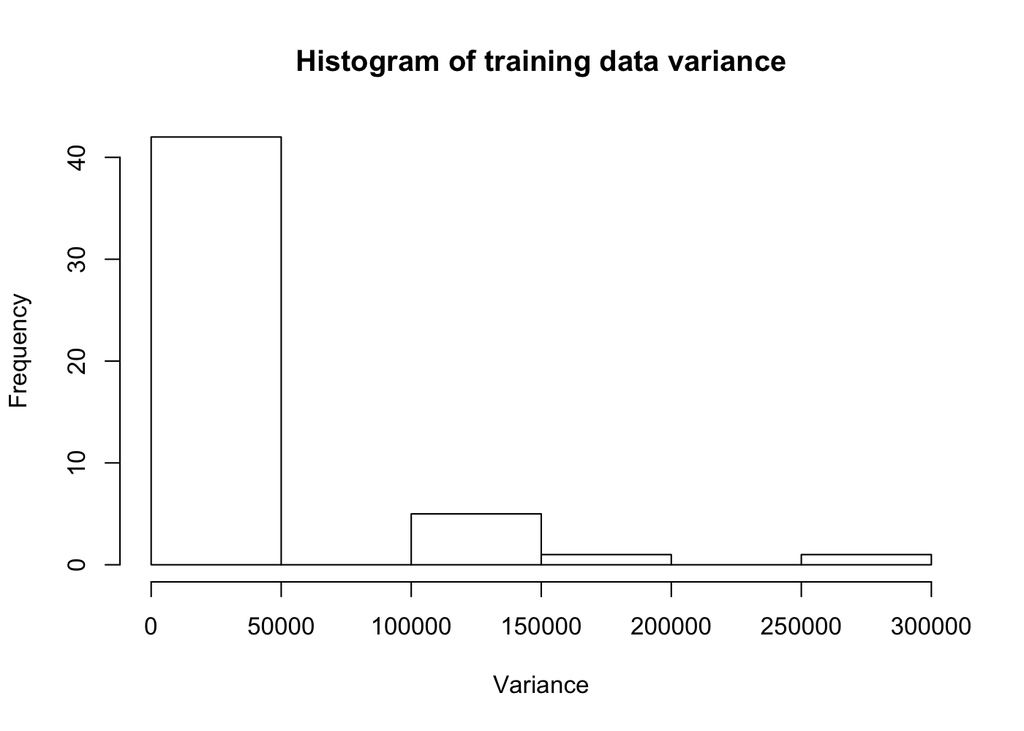

```r
hist(apply(training[,-c(1,54)],2,var), main = 'Histogram of training data variance',xlab = 'Variance')
```

We can see that there are some variables with high variance and other with low variance close to zero. The variable with small variance is **gyros_belt**:

```r
which(apply(training[,-c(1,54)],2,var) < .1)
```

[output not shown]

We decided to remove this variables since most are close or near to zero

```r
training <- training[,grep('gyros_belt',colnames(training),invert = TRUE)]
```

We keep the same variables for the test set:

```r
final.vars <- names(training)
testing <- testing[,colnames(testing) %in% c(final.vars,'problem_id')]
```

Before we can do any prediction tasks, we must convert the two categorical variables from string to factors:

```r
training$classe <- as.factor(training$classe)
training$user_name <- as.factor(training$user_name)
```